# Exploring NOAA Storm Database and Answering Questions

GenDoc94

2024-08-06

## Introduction

Storms and other severe weather events can cause both public health and economic problems for communities and municipalities. Many severe events can result in fatalities, injuries, and property damage, and preventing such outcomes to the extent possible is a key concern.

This project involves exploring the U.S. National Oceanic and Atmospheric Administration’s (NOAA) storm database. This database tracks characteristics of major storms and weather events in the United States, including when and where they occur, as well as estimates of any fatalities, injuries, and property damage

## Data Processing

```r
linkURL <- "https://d396qusza40orc.cloudfront.net/repdata%2Fdata%2FStormData.csv.bz2"
download.file(linkURL, destfile = "repdata_data_StormData.csv.bz2")
stormdb <- read.csv("repdata_data_StormData.csv.bz2", header = TRUE, sep = ",")
file.remove("repdata_data_StormData.csv.bz2")
```

2. Creating subset just to work better

```r
storm.selected <- stormdb %>%
        select(EVTYPE, FATALITIES, INJURIES, PROPDMG, PROPDMGEXP, CROPDMG, CROPDMGEXP)
```

3. Correcting PROPDMGEXP

```r
sort(unique(storm.selected$PROPDMGEXP))
```

```
##  [1] ""  "-" "?" "+" "0" "1" "2" "3" "4" "5" "6" "7" "8" "B" "h" "H" "K" "m" "M"
```

```r
storm.selected$PROPDMGEXP[(storm.selected$PROPDMGEXP == "") | (storm.selected$PROPDMGEXP == "-") | (storm.selected$PROPDMGEXP == "?") | (storm.selected$PROPDMGEXP == "+") | (storm.selected$PROPDMGEXP == "0")] <- 10^0
storm.selected$PROPDMGEXP[(storm.selected$PROPDMGEXP == "1")] <- 10^1
storm.selected$PROPDMGEXP[(storm.selected$PROPDMGEXP == "2") | (storm.selected$PROPDMGEXP == "h") | (storm.selected$PROPDMGEXP == "H")] <- 10^2
storm.selected$PROPDMGEXP[(storm.selected$PROPDMGEXP == "3") | (storm.selected$PROPDMGEXP == "k") | (storm.selected$PROPDMGEXP == "K")] <- 10^3
storm.selected$PROPDMGEXP[(storm.selected$PROPDMGEXP == "4")] <- 10^4
storm.selected$PROPDMGEXP[(storm.selected$PROPDMGEXP == "5")] <- 10^5
storm.selected$PROPDMGEXP[(storm.selected$PROPDMGEXP == "6") | (storm.selected$PROPDMGEXP == "m") | (storm.selected$PROPDMGEXP == "M")] <- 10^6
storm.selected$PROPDMGEXP[(storm.selected$PROPDMGEXP == "7")] <- 10^7
storm.selected$PROPDMGEXP[(storm.selected$PROPDMGEXP == "8")] <- 10^8
storm.selected$PROPDMGEXP[(storm.selected$PROPDMGEXP == "B")] <- 10^9
storm.selected$PROPDMGEXP <- as.numeric(storm.selected$PROPDMGEXP)
sort(unique(storm.selected$PROPDMGEXP))
```

[output not shown]

4. Correcting CROPDMGEXP

```r
sort(unique(storm.selected$CROPDMGEXP))
```

```
## [1] ""  "?" "0" "2" "B" "k" "K" "m" "M"
```

```r
storm.selected$CROPDMGEXP[(storm.selected$CROPDMGEXP == "") | (storm.selected$CROPDMGEXP == "?") | (storm.selected$CROPDMGEXP == "0")] <- 10^0
storm.selected$CROPDMGEXP[(storm.selected$CROPDMGEXP == "2")] <- 10^2
storm.selected$CROPDMGEXP[(storm.selected$CROPDMGEXP == "k") | (storm.selected$CROPDMGEXP == "K")] <- 10^3
storm.selected$CROPDMGEXP[(storm.selected$CROPDMGEXP == "m") | (storm.selected$CROPDMGEXP == "M")] <- 10^6
storm.selected$CROPDMGEXP[(storm.selected$CROPDMGEXP == "B")] <- 10^9
storm.selected$CROPDMGEXP <- as.numeric(storm.selected$CROPDMGEXP)
sort(unique(storm.selected$CROPDMGEXP))
```

```
## [1] 1e+00 1e+02 1e+03 1e+06 1e+09
```

5. Creating PROP, CROP and TOTAL DAMAGE VARIABLE

```r
storm.selected$PROP <- storm.selected$PROPDMG * storm.selected$PROPDMGEXP
storm.selected$CROP <- storm.selected$CROPDMG * storm.selected$CROPDMGEXP
storm.selected$DMG <- storm.selected$PROP + storm.selected$CROP
```

6. Creating data for plotting

```r
storm.plotting <- storm.selected %>% group_by(EVTYPE) %>% summarise(Fatalities = sum(FATALITIES), Injuries = sum(INJURIES), People = Fatalities + Injuries) %>% filter(People > 0) %>% arrange(desc(People))
storm.plotting2 <- storm.selected %>% group_by(EVTYPE) %>% summarise(TotalDamage = sum(DMG)) %>% filter(TotalDamage > 0) %>% arrange(desc(TotalDamage))
```

## Answering questions

### 1. Across the United States, which types of events (as indicated in the EVTYPE variable) are most harmful with respect to population health?

We can select the most harmful as the max of the sum of FATALITIES and INJURIES

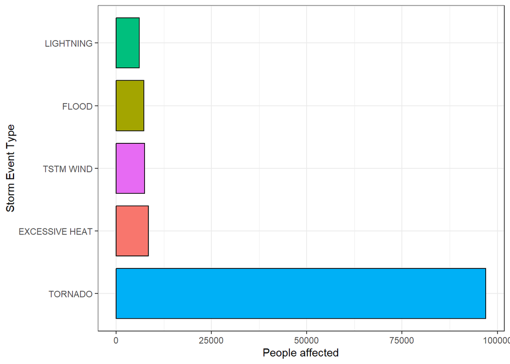

```r
g <- ggplot(storm.plotting[1:5, ],
            aes(x = reorder(EVTYPE, -People),
                y= People,
                fill = EVTYPE))
g +
        geom_col(show.legend = FALSE, width = 0.8, color="black") +
        coord_flip() +
        labs(x = "Storm Event Type",
             y = "People affected") +
        theme_bw()
```

```r
most_harmful <- storm.plotting[1, ]$EVTYPE
```

The most harmful event is **TORNADO**.

### 2. Across the United States, which types of events have the greatest economic consequences?

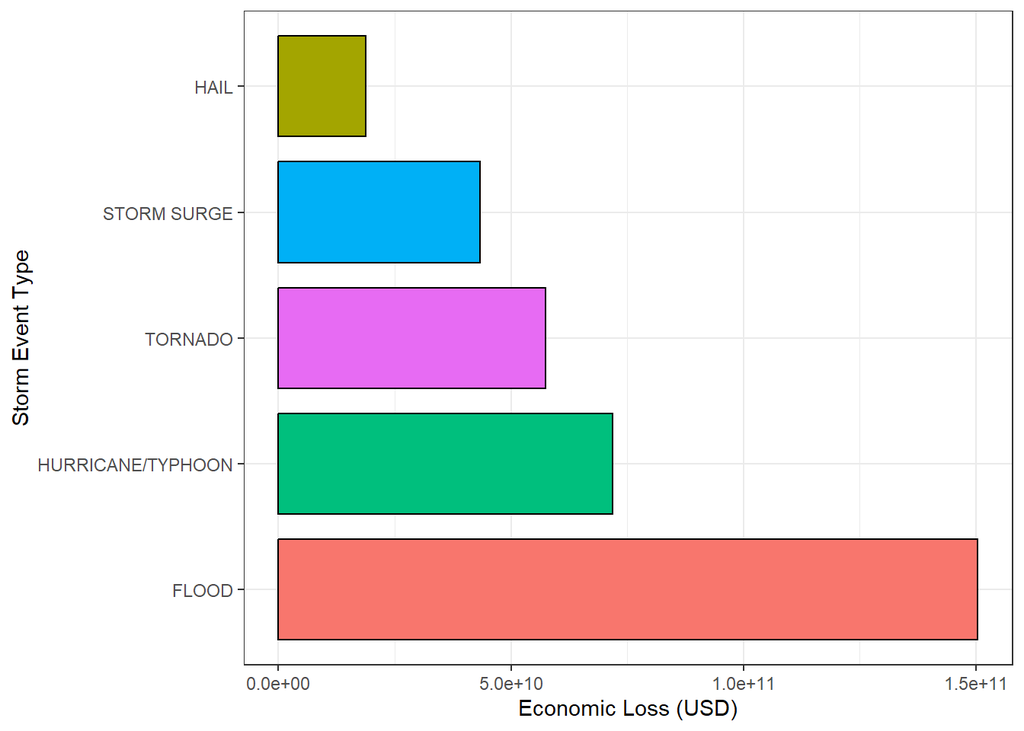

```r
g2 <- ggplot(storm.plotting2[1:5, ],
            aes(x = reorder(EVTYPE, -TotalDamage),
                y= TotalDamage,
                fill = EVTYPE))
g2 +
        geom_col(show.legend = FALSE, width = 0.8, color="black") +
        coord_flip() +
        labs(x = "Storm Event Type",
             y = "Economic Loss (USD)") +
        theme_bw()
```

```r
most_economic <- storm.plotting2[1, ]$EVTYPE
```

The worst economic event is **FLOOD**.